# Math219 Project 1

## Introduction

The following dataset is provided by "Mendely Data". It reports medical information and labratory reports of patients from the Iraqi society in 3 differnt catergories of diabetes: Diabetic, Non-Diabetic, Predict-Diabetic.

```python
import numpy as np
import pandas as pd
import seaborn as sns
import matplotlib.pyplot as plt
from sklearn.preprocessing import LabelEncoder
from scipy.stats import pointbiserialr
df = pd.read_csv("Dataset of Diabetes .csv")
```

## Preprocessing

```python
df = df.drop(columns=['HDL', 'LDL', 'VLDL', 'HbA1c','ID', "No_Pation"])

# Preprocess the data to ensure consistency
df['CLASS'] = df['CLASS'].str.strip().str.upper()
df['Gender'] = df['Gender'].str.strip().str.upper()
# Initialize LabelEncoder
label_encoder = LabelEncoder()
# Fit the encoder to the categorical column
label_encoder.fit(df['CLASS'])
# Transform the categorical column
df['CLASS_encoded'] = label_encoder.transform(df['CLASS'])

#detect missing values
missing_values = df.isnull().sum()
print("Missing values:\n", missing_values)
```

```
Missing values:
 Gender           0
AGE              0
Urea             0
Cr               0
Chol             0
TG               0
BMI              0
CLASS            0
CLASS_encoded    0
dtype: int64
```

```python
#There are no missing values, can move on to outlier analysis
#outlier anlysis on Urea
column = df['Urea']
Q1 = column.quantile(0.25)
Q3 = column.quantile(0.75)
IQR = Q3 - Q1
lower_bound = Q1 - 1.5 * IQR
upper_bound = Q3 + 1.5 * IQR
urea_outliers = column[(column < lower_bound) | (column > upper_bound)]
print("The outliers are:\nIndex", " Value\n", urea_outliers)
```

```
The outliers are:
Index  Value
 20     13.5
86     10.0
91      9.6
95     22.0
151    17.1
       ...
977    10.3
983     8.8
985    10.3
994    10.3
995    11.0
Name: Urea, Length: 65, dtype: float64
```

```python
#outlier anlysis on Cr
column = df['Cr']
Q1 = column.quantile(0.25)
Q3 = column.quantile(0.75)
IQR = Q3 - Q1
lower_bound = Q1 - 1.5 * IQR
upper_bound = Q3 + 1.5 * IQR
cr_outliers = column[(column < lower_bound) | (column > upper_bound)]
print("The outliers are:\nIndex", " Value\n", cr_outliers)
```

```
The outliers are:
Index  Value
 20     175
69       6
87     123
91     203
94     132
95     159
151    344
208    370
212    370
273    800
283    800
303    146
309    159
```

[output cut: 40 more lines]

```python
#outlier anlysis on Chol
column = df['Chol']
Q1 = column.quantile(0.25)
Q3 = column.quantile(0.75)
IQR = Q3 - Q1
lower_bound = Q1 - 1.5 * IQR
upper_bound = Q3 + 1.5 * IQR
chol_outliers = column[(column < lower_bound) | (column > upper_bound)]
print("The outliers are:\nIndex", " Value\n", chol_outliers)
```

```
The outliers are:
Index  Value
 20      0.5
41      9.5
48      9.5
99      0.0
176     9.5
177     9.5
342     0.6
345     0.6
412     8.5
415     8.5
431     8.8
523     9.9
524     9.8
526     9.3
621     8.8
662    10.3
667     9.7
709     9.1
724     1.2
742     8.4
776     9.7
821     9.2
826     8.1
830     8.0
831     8.0
921     9.8
970     8.6
Name: Chol, dtype: float64
```

```python
#outlier anlysis on TG
column = df['TG']
Q1 = column.quantile(0.25)
Q3 = column.quantile(0.75)
IQR = Q3 - Q1
lower_bound = Q1 - 1.5 * IQR
upper_bound = Q3 + 1.5 * IQR
tg_outliers = column[(column < lower_bound) | (column > upper_bound)]
print("The outliers are:\nIndex", " Value\n", tg_outliers)
```

```
The outliers are:
Index  Value
 64      5.9
91      5.9
92      5.3
98      5.3
108     5.3
149     5.3
208     6.0
212     6.0
302     5.1
315     6.8
319     6.8
426     5.1
436     5.3
```

[output cut: 43 more lines]

```python
#outlier anlysis on BMI
column = df['BMI']
Q1 = column.quantile(0.25)
Q3 = column.quantile(0.75)
IQR = Q3 - Q1
lower_bound = Q1 - 1.5 * IQR
upper_bound = Q3 + 1.5 * IQR
bmi_outliers = column[(column < lower_bound) | (column > upper_bound)]
print("The outliers are:\nIndex", " Value\n", bmi_outliers)
```

```
The outliers are:
Index  Value
 183    47.00
188    47.00
698    47.75
Name: BMI, dtype: float64
```

```python
print("Below is a summary of the number of outliers in each column\n")
print("Urea Outliers:",len(urea_outliers))
print("Cr Outliers:",len(cr_outliers))
print("Chol Outliers:",len(chol_outliers))
print("TG Outliers:",len(tg_outliers))
print("BMI Outliers:",len(bmi_outliers))
```

```
Below is a summary of the number of outliers in each column

Urea Outliers: 65
Cr Outliers: 52
Chol Outliers: 27
TG Outliers: 55
BMI Outliers: 3
```

## Summary Data Analysis

```
Summary for Gender
Gender
M    565
F    435
Name: count, dtype: int64

Summary for CLASS
CLASS
Y    844
N    103
P     53
Name: count, dtype: int64
```

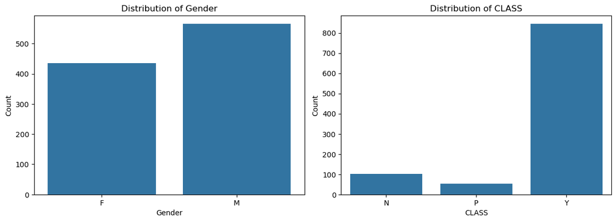

```python
for column in df.select_dtypes(include=['object']):
    print("Summary for", column)
    print(df[column].value_counts())
    print()

# Graphical representation
plt.figure(figsize=(12, 8))

# Bar plot for each categorical column
for i, column in enumerate(df.select_dtypes(include=['object'])):
    plt.subplot(2, 2, i+1)
    sns.countplot(data=df, x=column)
    plt.title(f'Distribution of {column}')
    plt.xlabel(column)
    plt.ylabel('Count')

plt.tight_layout()
plt.show()
```

```
Statistical Summary:
                AGE         Urea           Cr         Chol           TG  \
count  1000.000000  1000.000000  1000.000000  1000.000000  1000.000000
mean     53.528000     5.124743    68.943000     4.862820     2.349610
std       8.799241     2.935165    59.984747     1.301738     1.401176
min      20.000000     0.500000     6.000000     0.000000     0.300000
25%      51.000000     3.700000    48.000000     4.000000     1.500000
50%      55.000000     4.600000    60.000000     4.800000     2.000000
75%      59.000000     5.700000    73.000000     5.600000     2.900000
max      79.000000    38.900000   800.000000    10.300000    13.800000

               BMI
count  1000.000000
mean     29.578020
std       4.962388
min      19.000000
25%      26.000000
50%      30.000000
75%      33.000000
max      47.750000
```

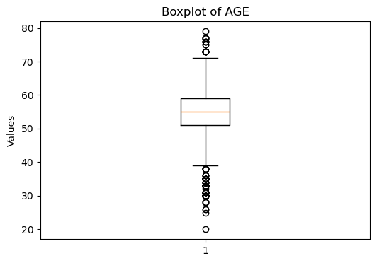

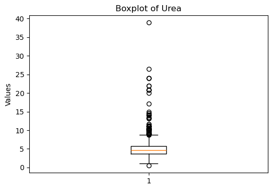

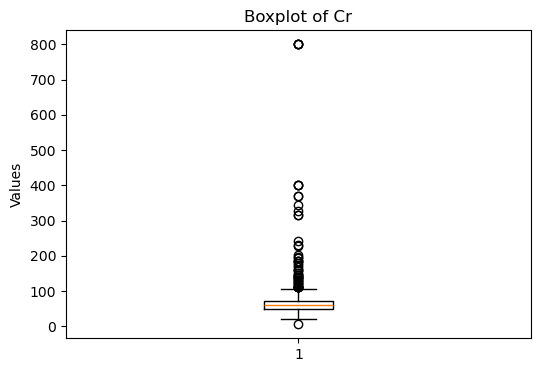

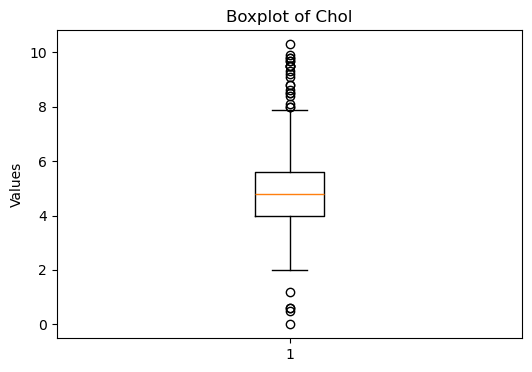

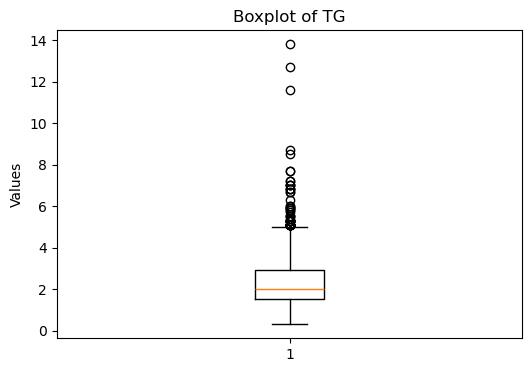

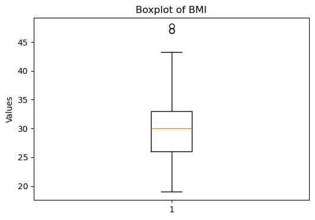

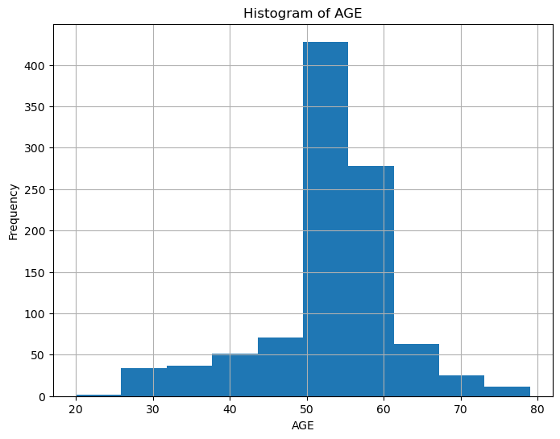

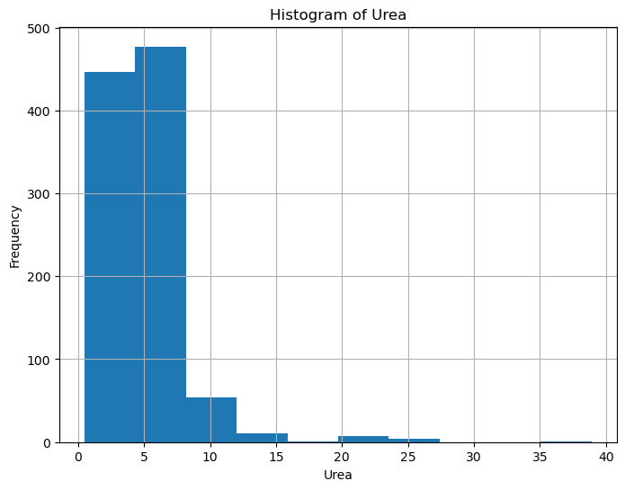

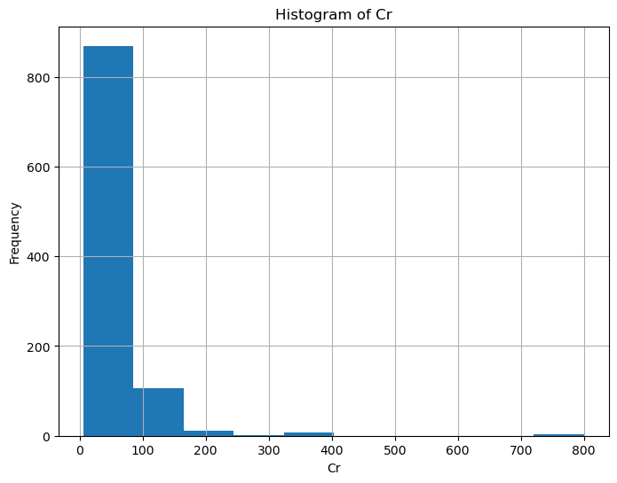

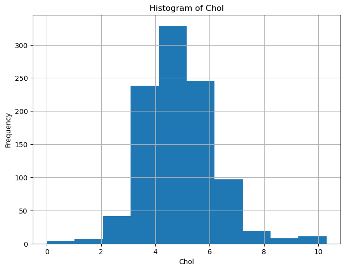

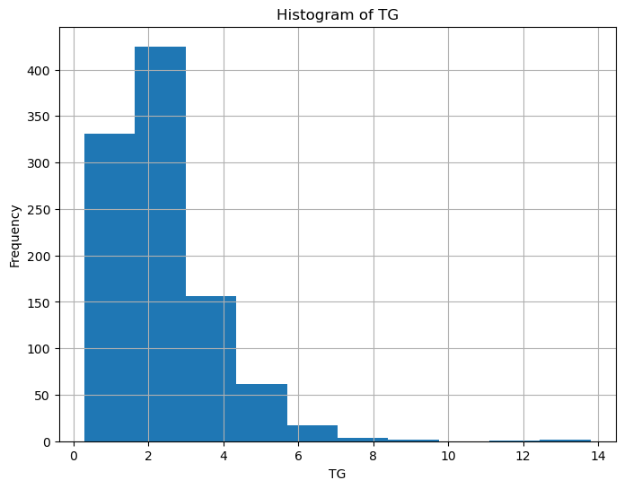

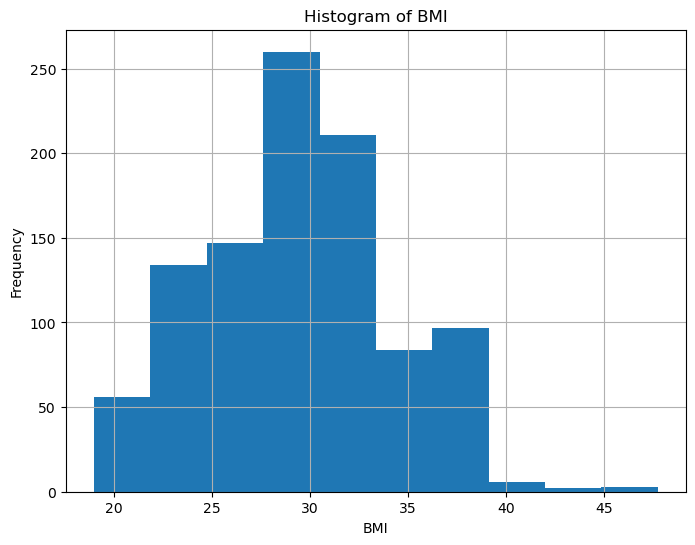

```python
# Statistical summary

summary =  df.drop(columns=['CLASS_encoded']).describe()
# Boxplot
print("Statistical Summary:\n", summary)
columns_to_include = ['AGE',"Urea", 'Cr', 'Chol', 'TG', 'BMI']
for column in df[columns_to_include]:
    plt.figure(figsize=(6, 4))
    plt.boxplot(df[column])
    plt.title(f'Boxplot of {column}')
    plt.ylabel('Values')
    plt.show()



# Histogram
for column in df[columns_to_include]:
    plt.figure(figsize=(8, 6))
    plt.hist(df[column], bins=10)  # Adjust the number of bins as needed
    plt.title(f'Histogram of {column}')
    plt.xlabel(column)
    plt.ylabel('Frequency')
    plt.grid(True)
    plt.show()
```

There is approximately amount of equal male and females labratory results in this dataset, in which most have diabetes(84.4%). The mean age for these patients is 53 years with the youngest patient being 20 and the oldest 79. Based off the histrograms of the results found in lab, the data for BMI= bmi index and Chol=cholesterol seems to follow a normal distribution. The data for TG=triglycerides,Cr=creatine, Urea appear to be right skewed. Further analysis of this data and possible correlations is analyzed below.

```python
#Correlation Between Cholesterol & Diabetes
#Class_encoded Values: 0 = Non-Diabetic, 1=Predict Diabetic, 2=Diabetic
correlation_coefficient, p_value = pointbiserialr(df['CLASS_encoded'], df['Chol'])
print("Point-biserial correlation coefficient:", correlation_coefficient)
print("p-value:", p_value)

#Correlation Between Age & Chol
column1 = 'AGE'
column2 = 'Chol'
correlation_coefficient = np.corrcoef(df['AGE'], df['Chol'])[0, 1]
print("Pearson correlation coefficient:", correlation_coefficient)

#Correlation Between Cr & Urea
column1 = 'Urea'
column2 = 'Cr'
correlation_coefficient = np.corrcoef(df['Urea'], df['Cr'])[0, 1]
print("Pearson correlation coefficient:", correlation_coefficient)
```

```
Point-biserial correlation coefficient: 0.16737461648529126
p-value: 1.0160572504528455e-07
Pearson correlation coefficient: 0.0366491842236855
Pearson correlation coefficient: 0.62413401439751
```

Although the correlation coefficent is low, the observed correlation between diabetes and cholesterol levels is statistically signifcant as indicated by the small p-value. There is no linear relationship between age and cholesterol as indicated by the small values 0.036~0 for the pearson correlation coefficient. There is a linear relationship between urea and creatine levels as indicated by the pearson correlation coeffcient >>0.

## Discussion

There are many types of labaratory results to unpack in this dataset. It would be appropriate to see if certain combinations of results can lead to diabetes. Specifically, can high cholesterol, high urea levels, high BMI values, and higher creatine values predict that a patient can have diabetes? Another aspect of this dataset is to explore other populations besdies Iraq and put emphasis on other characteristics besides diabetes as some of them are known to be related to diabetes. To observe this, we can see if age, country, urea levels, and bmi index can predict high cholesterol?